# Functional Response 5

Grace Henderson, Alyssa Obermayer, Christyn Geniesse

9/14/2020

## *Workplan*

To complete this assignment our group used email, Google docs, and MS Teams. The questions were divided via email, worked out individually on R, and answers were uploaded to the shared Google doc. There was asynchronous editing on the Google doc as well as some text back and forth. Code revision was done both individually and on Teams where all members participated to discuss our thoughts on the code and text answers. One member put together the document in R markdown and sent it to the rest of the group to do a final check prior to submission.

## *Problem 1*

For problem 1 we will recreate the “Sit-and-Wait Forager” figure 2.7, from our textbook, in R using the same parameters as in the book. This model looks at sit-and-wait foraging of a semi-circle in front of a predator in two different habitats, wet and dry, and compares the average energy gain per prey item versus cutoff distance in each habitat.

First, we input the parameters for the model

```r
# Initial conditions and parameters from the book

e = 10                             #Energy per prey item
ew = 0.1                           #Energy spent waiting
ep = 1                             #Energy spent pursuing
v = 0.5                            #Running speed of predator
rc = seq(0.005, 4.000, by = 0.005) #Cutoff distances
aw = 0.02                          #Prey arrival rate wet habitat
ad = 0.005                         #Prey arrival rate dry habitat
```

Next, we will generate equations to analyze the average energy gain per prey item in both the wet and dry habitats.

```r
#Wet habitat analysis
#Equation for time spent waiting in the wet habitat
tww <- 2/(aw * pi * (rc^2))

#Equation for average pursuit time
tp <- (4/3) * (rc/v)

#Equation for total average time in wet habitat
tiw <- (tww + tp)

#Equation for average energy per item in wet habitat
eiw <- (e) - (2 * ((ew)/(aw * pi * (rc^2)))) - ((4/3) * ((ep * rc)/(v)))

#Equation for average energy gain per item in wet habitat
etw <- (eiw)/(tiw)

#Dry habitat analysis
#Equation for time spent waiting in the dry habitat
twd <- 2/(ad * pi * (rc^2))

#Equation for total average time in wet habitat
tid <- (twd + tp)

#Equation for average energy per item in wet habitat
eid <- (e) - (2 * ((ew)/(ad * pi * (rc^2)))) - ((4/3) * ((ep * rc)/(v)))

#Equation for average energy gain per item in wet habitat
etd <- (eid)/(tid)
```

Finally, with the quantitative information determined above we can generate the plot.

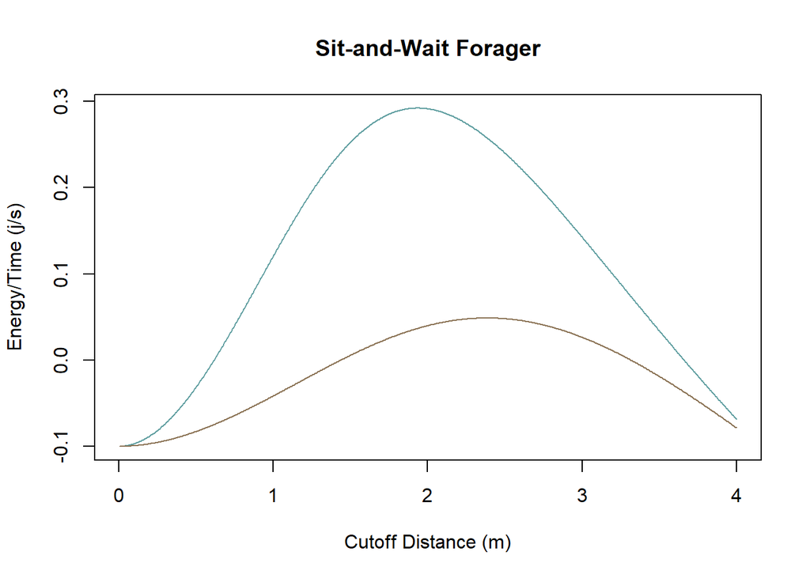

```r
#Sit and wait foraging plot
plot(etw~rc,
     type = "l",
     xlab = "Cutoff Distance (m)",
     ylab = "Energy/Time (j/s)",
     main = "Sit-and-Wait Forager",
     col = "cadetblue")
lines(etd~rc,
      col = "burlywood4")
```

## *Problem 2*

Use R to rewrite and run the bumblebee function in section 2.4, p 53-54. Produce Figure 2.10.

```r
#Create a function which contains a loop, to generate the energy gained at each of 10 flower positions

bee <- function(P, eb, ew, ef, ee, tb, tw, tf, te, n){
  netB <<- 0;                         #Empty object for the loop output
  sumi <- 0;

for (i in 1:n){

sumi=sumi+(-1.7*i+20.19)              #Expected caloric reward for ith flower position

net <- (P * sumi - eb - P * ew * (i-1) - P * i * ef - ee * (1-P)) / (tb + P * tw * (i-1) + P * i * tf + te * (1-P))            #The bee foraging model from the book
netB[i] <<- net                       #Store the loop output

}
}

bumble <- bee(P=0.375, eb=0.09, ew=0.07, ef=0.02, ee=0.01, tb= 4.4, tw=3.3, tf=14.7, te=8.9, n=10)                         #Run the function with the parameters as defined in the book
```

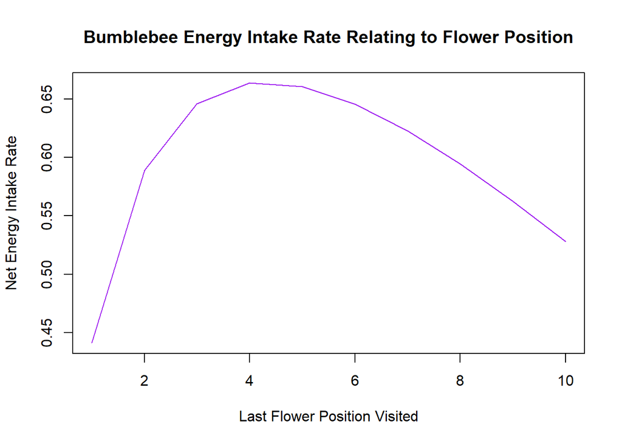

```r
#Recreate the figure on page 53
position <- seq(from=1, to=10, length.out=10)

plot(netB ~ position, type = "l", ylab = "Net Energy Intake Rate", xlab = "Last Flower Position Visited", col = "purple", main = "Bumblebee Energy Intake Rate Relating to Flower Position")
```

According to this model, at these parameters, it is optimal for the bee to move to a new plant after the 4th plower position.

Now imagine bees in two other areas. In one area the plants grow more densely than in the situation you have already modeled. Change 1 parameter that would represent this situation and explain why you chose that parameter. How does that change the number of flowers visited on a plant? Does it take a large change in the parameter chosen to change the number of flowers visited?

```r
#Rerun the function to re-save the new parameters in a new output

bee2 <- function(P, eb, ew, ef, ee, tb, tw, tf, te, n){
  netB2 <<- 0;
  sumi <- 0;

for (i in 1:n){

sumi=sumi+(-1.7*i+20.19)
net2 <- (P * sumi - eb - P * ew * (i-1) - P * i * ef - ee * (1-P)) / (tb + P * tw * (i-1) + P * i * tf + te * (1-P))
netB2[i] <<- net2

}
}

bumble2 <- bee2(P=0.375, eb=0.09, ew=0.07, ef=0.02, ee=0.01, tb=0.5, tw=3.3, tf=14.7, te=8.9, n=10)                         #Flying time between flowers changed to 0.5
```

Imagine a second set of meadows where flowers have less nectar due to drier conditions. Choose 1 parameter to change to represent this situation. How does that change the number of flowers visited on a plant? Does it take a large change in that parameter to change the number of flowers visited? Use equations and/or plots to support your answers.

```r
#Rerun the function to re-save the new parameters in a new output

bee3 <- function(P, eb, ew, ef, ee, tb, tw, tf, te, n){
  netB3 <<- 0;
  sumi <- 0;

for (i in 1:n){

sumi=sumi+(-1.7*i+15)                 #Energy gained per flower reduced to 15 calories
net3 <- (P * sumi - eb - P * ew * (i-1) - P * i * ef - ee * (1-P)) / (tb + P * tw * (i-1) + P * i * tf + te * (1-P))
netB3[i] <<- net3

}
}

bumble3 <- bee3(P=0.375, eb=0.09, ew=0.07, ef=0.02, ee=0.01, tb=4.4, tw=3.3, tf=14.7, te=8.9, n=10)
```

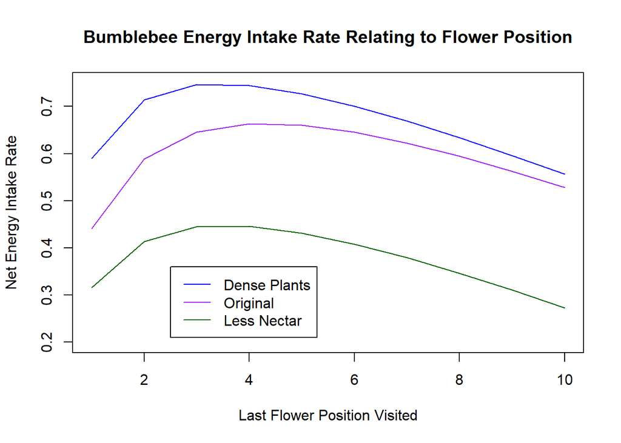

```r
#Plot the models with the 3 different parameters

plot(netB ~ position, type = "l", ylim=c(0.20,0.75), ylab = "Net Energy Intake Rate", xlab = "Last Flower Position Visited", col = "purple", main = "Bumblebee Energy Intake Rate Relating to Flower Position")
lines(netB2 ~ position, col="blue")
lines(netB3 ~ position, col="darkgreen")
legend(x=2.5,y=0.36,legend=c("Dense Plants", "Original", "Less Nectar"),col =c("blue","purple", "darkgreen"),lty=c(1, 1, 1))
```

When the plants are denser, we assumed the flying time between plants would be shorter. In that scenario, it is optimal for the bee to switch plants after the 3rd flower position. In the scenario with drought and less nectar in each flower, we assumed each flower would yield fewer calories. In that scenario, it is still optimal for the bee to visit the 4th flower before moving on. The bee simply receives less net energy overall with less nectar.